# Data Preprocessing Report

EU Paediatric Clinical Trials - Pipeline Audit

October 22, 2026

# 1. Dataset Overview

51,715

trials in final cache

39,090

source EUCTR

12,625

source CTIS

81

columns

1.4 s

cache load time

The report audits the cache at /shiny_trials/shiny_trials/trials_cache.rds. Logs are read from /shiny_trials/shiny_trials/data; the SQLite source database is /shiny_trials/shiny_trials/data/trials.sqlite.

## Register Mix

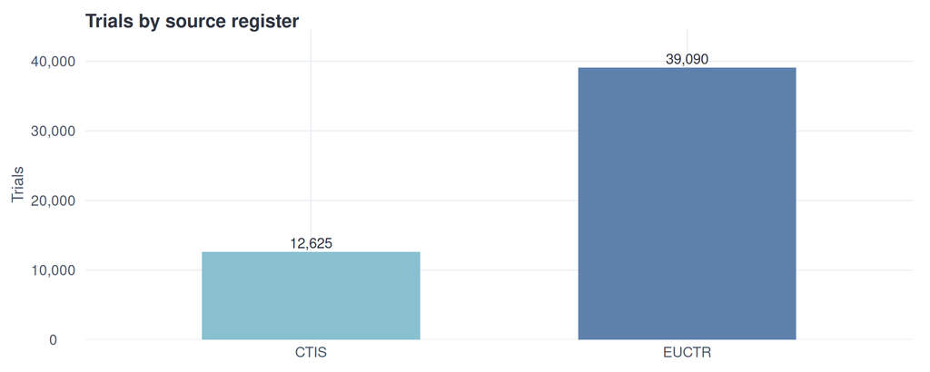

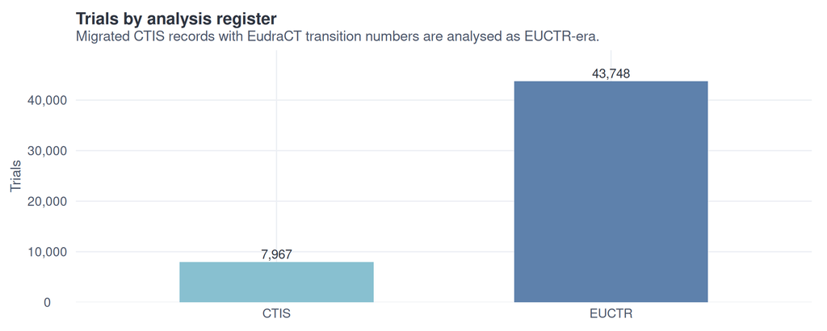

## Key Field Completeness

| Column | Type | Non-missing | Complete (%) |
| --- | --- | --- | --- |
| transition_eudract_number | character | 4658 | 9 |
| days_to_decision | numeric | 45089 | 87.2 |
| substance_label | character | 45119 | 87.2 |
| Full_title | character | 51469 | 99.5 |
| sponsor_label | character | 51566 | 99.7 |
| sponsor_type | character | 51566 | 99.7 |
| phase | character | 51643 | 99.9 |
| _id | character | 51715 | 100 |
| CT_number | character | 51715 | 100 |
| register | character | 51715 | 100 |

[output cut: 10 more lines]

# 2. Deduplication Pipeline

The dedup audit compares raw SQLite row identifiers with the final cache. EUCTR country variants and CTIS amendments are counted directly from raw IDs; cross-register and final removals are the remaining difference between the deduplicated raw universe and the cache.

## Waterfall

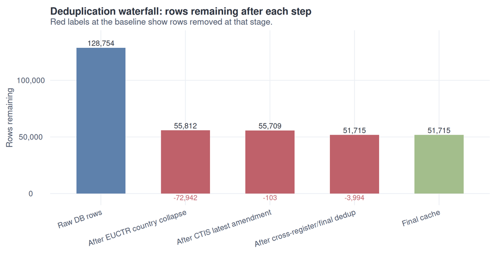

Deduplication stages

| Step | Logic | Rows removed | Rows remaining |
| --- | --- | --- | --- |
| Raw DB | All raw records fetched from SQLite | NA | 128,754 |
| EUCTR country collapse | Strip EUCTR member-state suffix and keep one base trial | 72,942 | 55,812 |
| CTIS latest amendment | Strip CTIS amendment suffix and keep the latest version | 103 | 55,709 |
| Cross-register / final dedup | Prefer CTIS over duplicate EUCTR records and apply final cache exclusions | 3,994 | 51,715 |
| Analysis label | Set analysis_register to EUCTR for migrated CTIS records | 0 | 51,715 |

## EUCTR Country Variants

| Base trial ID | Countries in raw DB | Country variants | Kept in cache |
| --- | --- | --- | --- |
| 2009-011360-10 | 23 | AT, BE, BG, CZ, DE, DK, EE, ES, FI, FR, GB, GR, HU, IE, IT, LT, LV, NL, NO, PT, SE, SI, SK | True |
| 2009-011360-10 | 23 | AT, BE, BG, CZ, DE, DK, EE, ES, FI, FR, GB, GR, HU, IE, IT, LT, LV, NL, NO, PT, SE, SI, SK | True |
| 2009-011360-10 | 23 | AT, BE, BG, CZ, DE, DK, EE, ES, FI, FR, GB, GR, HU, IE, IT, LT, LV, NL, NO, PT, SE, SI, SK | True |
| 2009-011360-10 | 23 | AT, BE, BG, CZ, DE, DK, EE, ES, FI, FR, GB, GR, HU, IE, IT, LT, LV, NL, NO, PT, SE, SI, SK | True |
| 2009-011360-10 | 23 | AT, BE, BG, CZ, DE, DK, EE, ES, FI, FR, GB, GR, HU, IE, IT, LT, LV, NL, NO, PT, SE, SI, SK | True |
| 2009-011360-10 | 23 | AT, BE, BG, CZ, DE, DK, EE, ES, FI, FR, GB, GR, HU, IE, IT, LT, LV, NL, NO, PT, SE, SI, SK | True |
| 2009-011360-10 | 23 | AT, BE, BG, CZ, DE, DK, EE, ES, FI, FR, GB, GR, HU, IE, IT, LT, LV, NL, NO, PT, SE, SI, SK | True |
| 2009-011360-10 | 23 | AT, BE, BG, CZ, DE, DK, EE, ES, FI, FR, GB, GR, HU, IE, IT, LT, LV, NL, NO, PT, SE, SI, SK | True |
| 2009-011360-10 | 23 | AT, BE, BG, CZ, DE, DK, EE, ES, FI, FR, GB, GR, HU, IE, IT, LT, LV, NL, NO, PT, SE, SI, SK | True |
| 2009-011360-10 | 23 | AT, BE, BG, CZ, DE, DK, EE, ES, FI, FR, GB, GR, HU, IE, IT, LT, LV, NL, NO, PT, SE, SI, SK | True |

[output cut: 10 more lines]

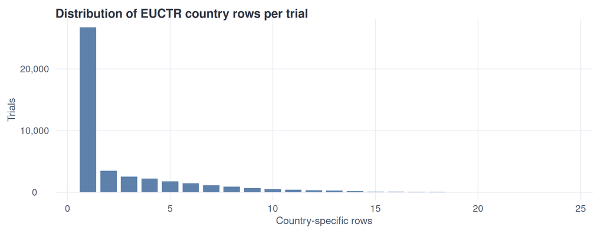

## CTIS Amendment Versions

| Base CTIS ID | Versions in DB | Latest version | Latest raw ID | Latest kept in cache | All versions |
| --- | --- | --- | --- | --- | --- |
| 2023-504439-42 | 3 | 3 | 2023-504439-42-03 | True | 2023-504439-42-00 -&gt; 2023-504439-42-01 -&gt; 2023-504439-42-03 |
| 2022-500030-28 | 2 | 1 | 2022-500030-28-01 | True | 2022-500030-28-00 -&gt; 2022-500030-28-01 |
| 2022-500044-38 | 2 | 1 | 2022-500044-38-01 | True | 2022-500044-38-00 -&gt; 2022-500044-38-01 |
| 2022-500185-94 | 2 | 1 | 2022-500185-94-01 | True | 2022-500185-94-00 -&gt; 2022-500185-94-01 |
| 2022-500228-31 | 2 | 1 | 2022-500228-31-01 | True | 2022-500228-31-00 -&gt; 2022-500228-31-01 |
| 2022-500410-26 | 2 | 1 | 2022-500410-26-01 | True | 2022-500410-26-00 -&gt; 2022-500410-26-01 |
| 2022-500535-36 | 2 | 1 | 2022-500535-36-01 | True | 2022-500535-36-00 -&gt; 2022-500535-36-01 |
| 2022-500536-11 | 2 | 1 | 2022-500536-11-01 | True | 2022-500536-11-00 -&gt; 2022-500536-11-01 |
| 2022-500721-32 | 2 | 1 | 2022-500721-32-01 | True | 2022-500721-32-00 -&gt; 2022-500721-32-01 |
| 2022-501006-34 | 2 | 1 | 2022-501006-34-01 | True | 2022-501006-34-00 -&gt; 2022-501006-34-01 |

[output cut: 15 more lines]

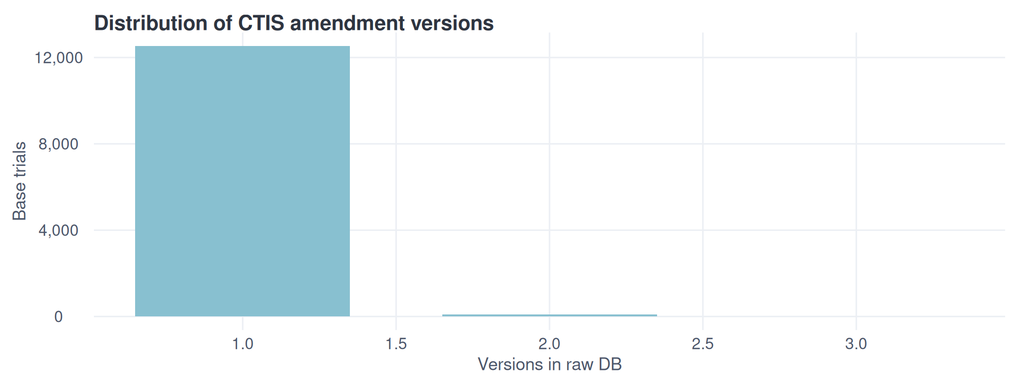

## Cross-Register Checks

| EUCTR ID | CTIS ID | Shared title key | EUCTR status | CTIS status |
| --- | --- | --- | --- | --- |
| 2011-005766-38-PL | 2022-500079-30-00 | a phase 3 multicenter randomized double blind placebo controlled trial to evalua | Completed | Completed |
| 2018-000601-22-DE | 2022-500079-30-00 | a phase 3 multicenter randomized double blind placebo controlled trial to evalua | Completed | Completed |
| 2011-004844-23-ES | 2022-500090-13-00 | a phase 2 randomized double blind placebo controlled study to evaluate the effec | Completed | Completed |
| 2011-004845-42-CZ | 2022-500090-13-00 | a phase 2 randomized double blind placebo controlled study to evaluate the effec | Completed | Completed |
| 2008-001936-11-BE | 2022-500257-16-00 | a phase 3 multicenter randomized double blind study to evaluate the safety and e | Completed | Ongoing |
| 2013-001669-17-BE | 2022-500308-23-00 | a randomised controlled assessor blind parallel groups multicentre multinational | Completed | Ongoing |
| 2021-001785-38-AT | 2022-500308-23-00 | a randomised controlled assessor blind parallel groups multicentre multinational | Completed | Ongoing |
| 2018-001133-40-GB | 2022-500488-10-00 | an open label study to evaluate the safety and pharmacokinetics of migalastat hc | Administrative | Completed |
| 2018-000265-37-ES | 2022-500694-14-00 | phase 1 2 study investigating safety tolerability pharmacokinetics and prelimina | Completed | Completed |
| 2004-002016-28-AT | 2022-500699-76-00 | a phase 3 randomized double blind placebo controlled study to evaluate the effic | Completed | Ongoing |

[output cut: 90 more lines]

| EUCTR base ID | EUCTR status | CTIS match | Match method |
| --- | --- | --- | --- |
| 2005-003096-20 | Trial now transitioned | 2024-519009-36-01 | transition EudraCT number |
| 2006-003377-27 | Trial now transitioned | 2024-514756-32-00 | transition EudraCT number |
| 2007-000838-39 | Trial now transitioned | 2024-515247-28-00 | transition EudraCT number |
| 2007-001375-11 | Trial now transitioned | 2024-518269-92-00 | transition EudraCT number |
| 2007-003928-37 | Trial now transitioned | 2023-507526-17-00 | transition EudraCT number |
| 2008-002260-33 | Trial now transitioned | 2024-510784-36-00 | transition EudraCT number |
| 2008-006158-16 | Trial now transitioned | 2024-515487-31-00 | transition EudraCT number |
| 2009-015878-35 | Trial now transitioned | 2023-507001-34-00 | transition EudraCT number |
| 2009-016448-38 | Trial now transitioned | 2024-514844-10-00 | transition EudraCT number |
| 2009-017349-77 | Trial now transitioned | 2024-515253-25-00 | transition EudraCT number |

[output cut: 3663 more lines]

# 3. Register, Age, Phase, Status, and Dates

## Age Group

6,881

eligible under 18

47,865

eligible 18 or older

200

unknown age group

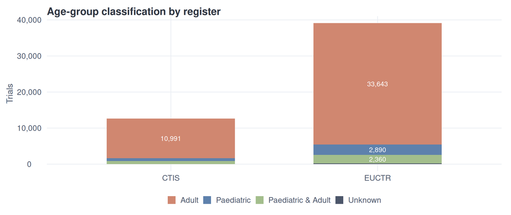

Adult / paediatric classification

| Age group | Trials | % of cache |
| --- | --- | --- |
| Adult | 44,634 | 86.3% |
| Paediatric | 3,650 | 7.1% |
| Paediatric & Adult | 3,231 | 6.2% |
| Unknown | 200 | 0.4% |

## Phase

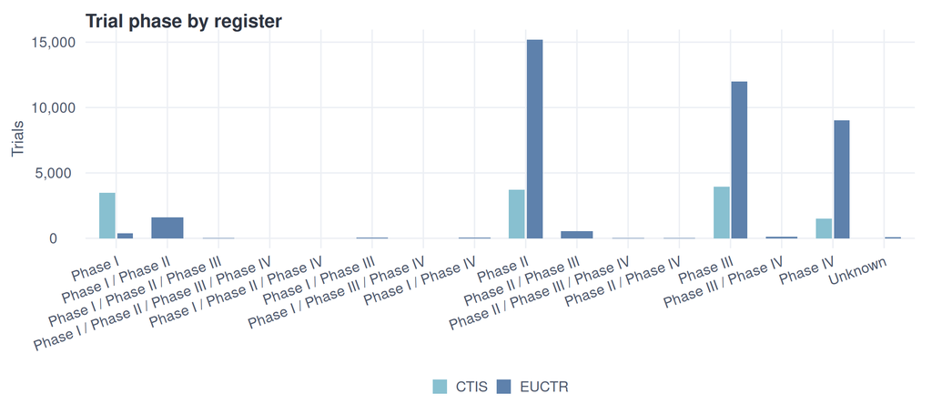

| Register | Raw | Normalised | N trials |
| --- | --- | --- | --- |
| EUCTR | Phase II | Phase II | 15205 |
| EUCTR | Phase III | Phase III | 11988 |
| EUCTR | Phase IV | Phase IV | 9013 |
| CTIS | Therapeutic exploratory (Phase II) | Phase II | 3699 |
| CTIS | Therapeutic confirmatory (Phase III) | Phase III | 3518 |
| EUCTR | Phase I / Phase II | Phase I / Phase II | 1598 |
| CTIS | Therapeutic use (Phase IV) | Phase IV | 1283 |
| CTIS | Human Pharmacology (Phase I)- Other | Phase I | 1145 |
| CTIS | Human Pharmacology (Phase I)- First administration to humans | Phase I | 862 |
| CTIS | Phase I and Phase II (Integrated)- Other | Phase I | 656 |

[output cut: 18 more lines]

## Status

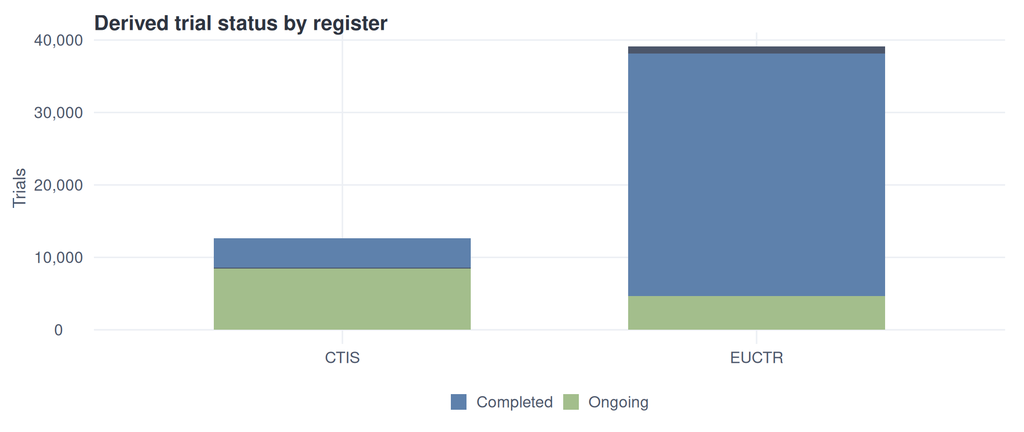

| Register | Raw | Normalised | N trials |
| --- | --- | --- | --- |
| CTIS | Ended | Completed | 4028 |
| CTIS | Ongoing, recruiting | Ongoing | 3935 |
| CTIS | Ongoing, recruitment ended | Ongoing | 2192 |
| CTIS | Authorised, recruitment pending | Ongoing | 1383 |
| CTIS | Authorised, recruiting | Ongoing | 826 |
| CTIS | Temporarily halted | Ongoing | 120 |
| CTIS | Not authorised | Not Authorised | 117 |
| CTIS | Expired | Not Authorised | 10 |
| CTIS | Under evaluation | Not Authorised | 5 |
| CTIS | Suspended | Ongoing | 4 |

[output cut: 11 more lines]

## Dates and Decision Lag

51,715

parsed submission dates

51,694

decision dates

16

completed with no decision date

47

median days to decision

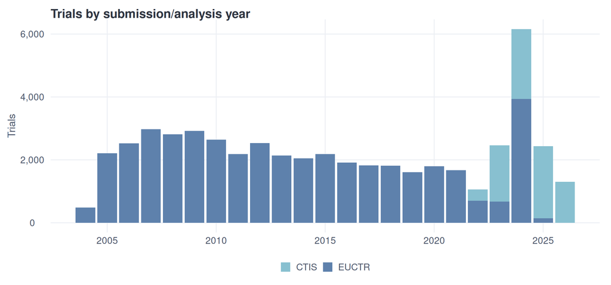

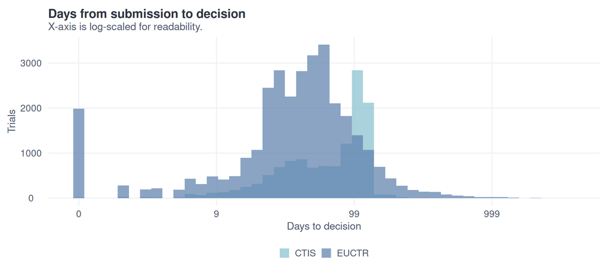

# 4. Field Normalisation Audits

## Country

128,754

country entries

4,356

unique raw values

2,990

unique normalised values

121,222

entries changed

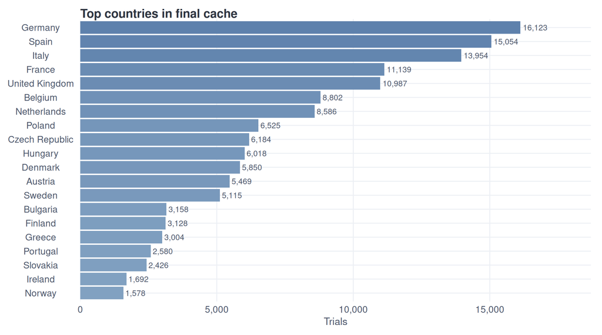

## MedDRA Terms

51,715

MedDRA term entries

12,245

unique raw values

11,314

unique normalised values

7,823

entries changed

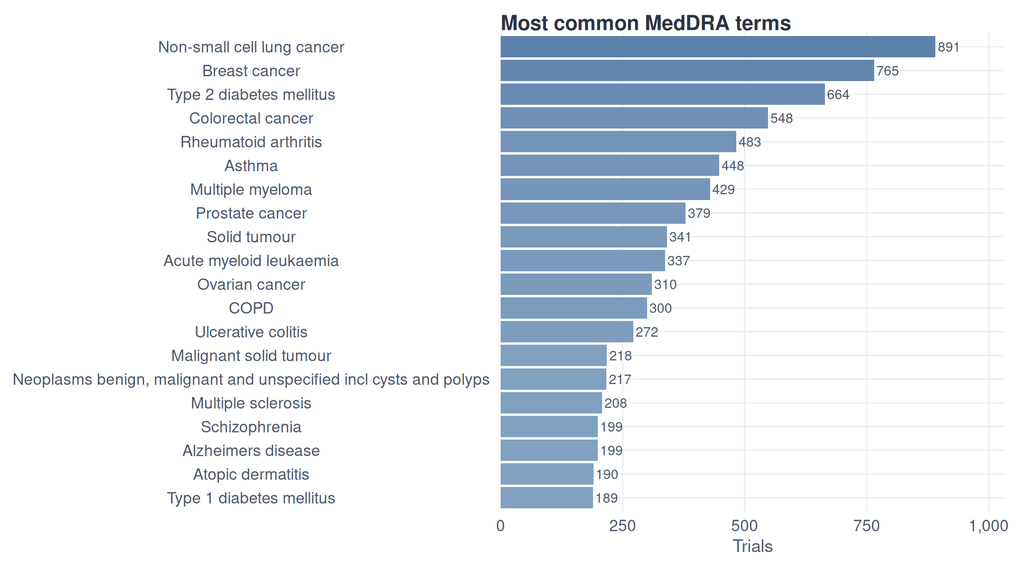

## Organ Class

51,715

organ-class entries

1,269

unique raw values

556

unique normalised values

26,603

entries changed

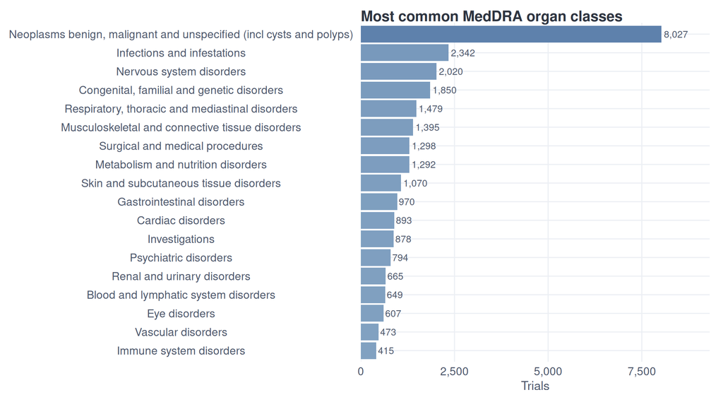

## Sponsor Names

Sponsor labels come from a **model-built canonical registry** (v2), which replaced the deterministic matcher and its ~16,500 committed alias rows. Raw strings are blocked offline, each block is named once with every variant visible, leftover strings are assigned by picking from a candidate list, duplicate entries are merged, and one script emits the app-facing labels.

The label the app displays is resolved by an explicit precedence chain, and the top of it is not the pipeline:

| Rank | Source | Where |
| --- | --- | --- |
| 1 | **Human curation** | `config/review_ledger/review_decisions.csv` |
| 2 | Pipeline canonical | `data/trial_sponsor_labels.csv` |
| 3 | Raw sponsor string | fallback when neither exists |

The ledger is read on every app load and never enters `trials_cache.rds`, so a curator’s decision is live on the next start without a cache rebuild.

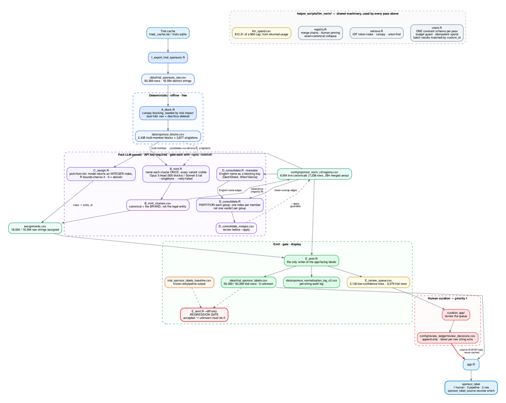

Sponsor normalisation v2. Blue is deterministic, violet is model-driven, green is what the app reads.

16,696

distinct raw strings

51,566

trial rows labelled

7,063

canonical sponsors

2,128

awaiting human review

**Collapse**  
**16,696** distinct raw strings collapse to **7,063** canonical sponsors — a 2.4x reduction. 0 string(s) carry no canonical. Consolidation merged a further **284** duplicate entries away.

### Who sponsors these trials

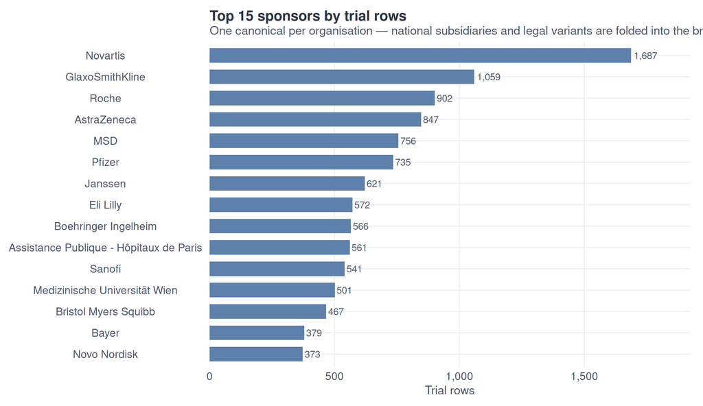

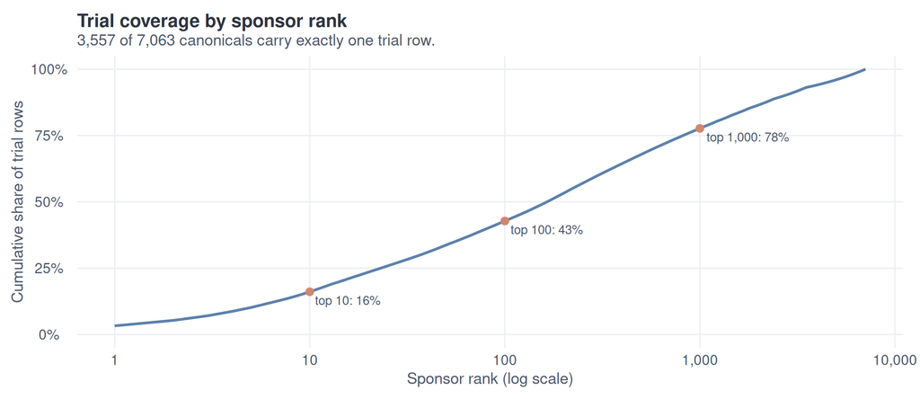

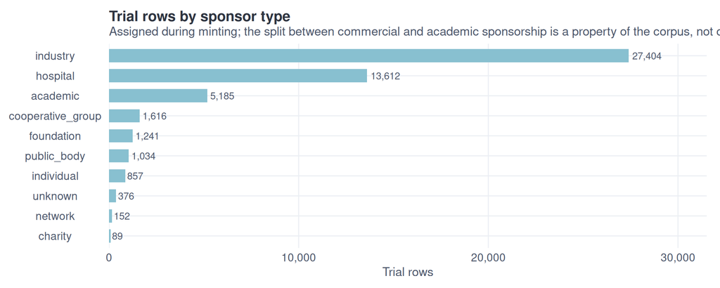

### How confident is the registry

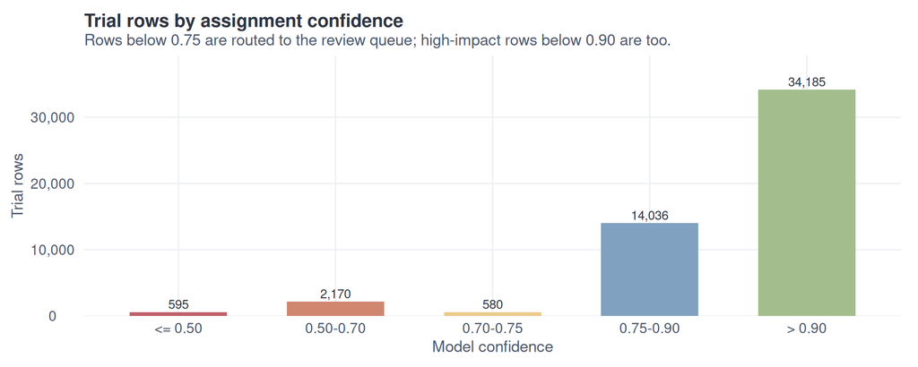

### What still needs a human

**Review queue**  
**2,128** raw strings carrying **3,499** trial rows (6.8% of all rows) are queued for confirmation. These are proposals, not decisions — nothing here changes a displayed label until a reviewer acts on it.

**Human decisions recorded**  
**None yet.** Every label on this page is model output. The precedence chain is wired and tested, so the first curated decision takes effect on the next app start — but nothing has been human-verified so far.

Highest-impact rows awaiting review — curate these first

| raw_sponsor | proposed | confidence | n_trials | review_reason |
| --- | --- | --- | --- | --- |
| Karolinska University Hospital | Karolinska Universitetssjukhuset | 0.88 | 98 | high impact, middling confidence |
| Amsterdam UMC Stichting | Amsterdam UMC | 0.88 | 69 | high impact, middling confidence |
| Merck KGaA | Merck KGaA | 0.85 | 68 | high impact, middling confidence |
| Academic Medical Center | Academic Medical Center | 0.70 | 66 | low confidence |
| Amsterdam UMC | Amsterdam UMC | 0.88 | 58 | high impact, middling confidence |
| University of Cologne | University of Cologne | 0.85 | 51 | high impact, middling confidence |
| University of Dundee | University of Dundee | 0.86 | 47 | high impact, middling confidence |
| ISTITUTO NAZIONALE PER LA CURA TUMORI | Fondazione IRCCS Istituto Nazionale dei Tumori | 0.82 | 46 | high impact, middling confidence |
| Merck Healthcare KGaA | Merck KGaA | 0.85 | 38 | high impact, middling confidence |
| FONDAZIONE CENTRO S. RAFFAELE DEL MONTE TABOR | Fondazione Centro San Raffaele del Monte Tabor | 0.75 | 33 | high impact, middling confidence |
| Vaestra Goetalandsregionen | Västra Götalandsregionen | 0.85 | 31 | high impact, middling confidence |
| Cambridge University Hospitals NHS Foundation Trust | Cambridge University Hospitals NHS Foundation Trust | 0.88 | 29 | high impact, middling confidence |
| Region Skane | Region Skåne | 0.85 | 28 | high impact, middling confidence |
| UMCG | Universitair Medisch Centrum Groningen | 0.85 | 26 | high impact, middling confidence |
| Helse Bergen HF | Helse Bergen | 0.85 | 25 | high impact, middling confidence |

## Substance Names

Substance normalisation was rewritten as v2. The premise of the rewrite is that substances, unlike sponsors, already have a canonical vocabulary: ChEMBL’s `pref_name` plus the EMA medicines report. That vocabulary is applied first and deterministically, and a model is asked only about what it could not place.

| Pass | What it does | Model |
| --- | --- | --- |
| `A_resolve` | exact match against ChEMBL + EPAR, placebo rule, junk filter | none |
| `B_assign` | pick-from-list over retrieved candidates | Sonnet 5 |
| `C_mint` | name what B could not place, cluster-at-a-time | Opus 5 / Sonnet 5 |
| `D_consolidate` | salt rollup (deterministic) + merge partition | Opus 5 |
| `E_emit` | per-trial labels, review queue, regression diff | none |

The canonical is the **INN base**: `Methotrexate` absorbs `methotrexate sodium`, `Metoject` and `Methotrexat 10mg Tabletten`, with the salt and brand kept in separate registry columns. Where ChEMBL states a USAN that differs from the INN, the INN is used — this is an EU trial corpus.

102,509

raw trial-substance pairs

34,625

distinct raw strings

8,911

substances displayed

45,119

trials with a label

4,673

awaiting human review

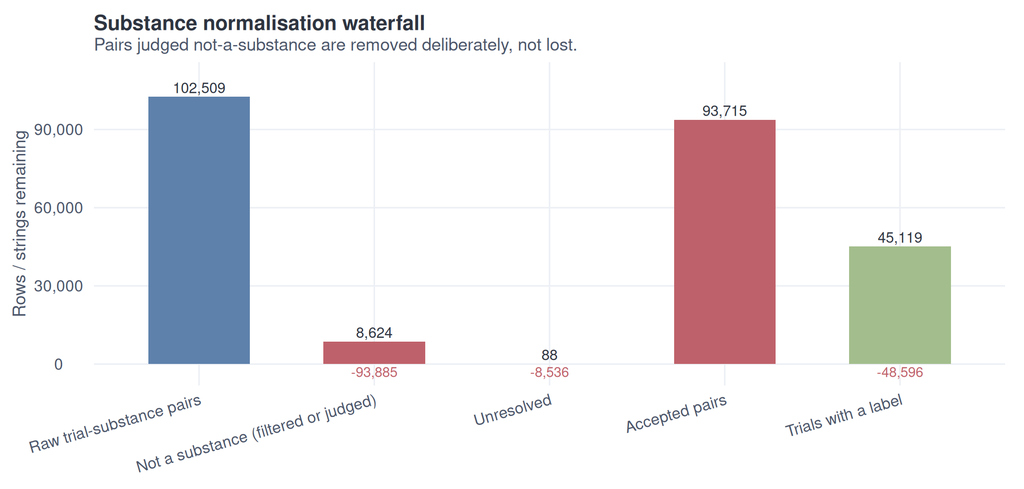

Substance normalisation stage counts

| Step | Count | Change from previous step |
| --- | --- | --- |
| Raw trial-substance pairs | 102,509 | NA |
| Not a substance (filtered or judged) | 8,624 | 93,885 |
| Unresolved | 88 | 8,536 |
| Accepted pairs | 93,715 | -93,627 |
| Trials with a label | 45,119 | 48,596 |

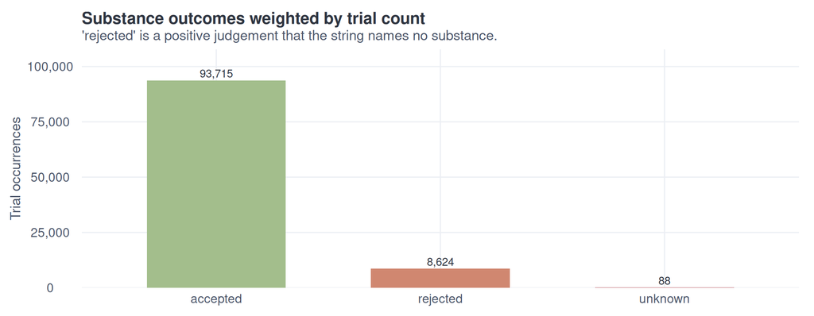

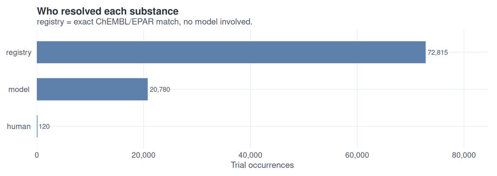

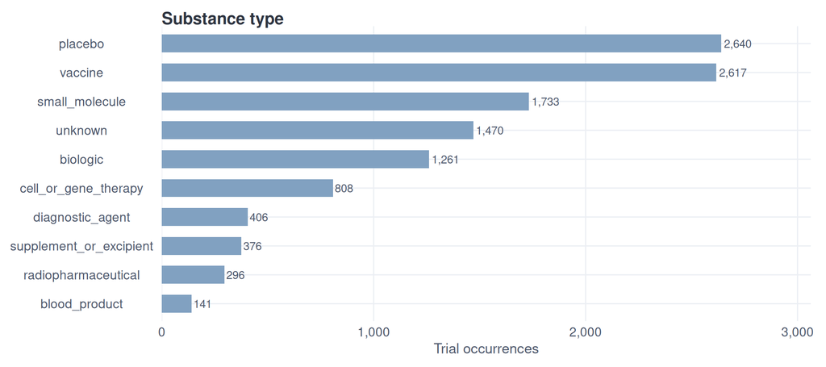

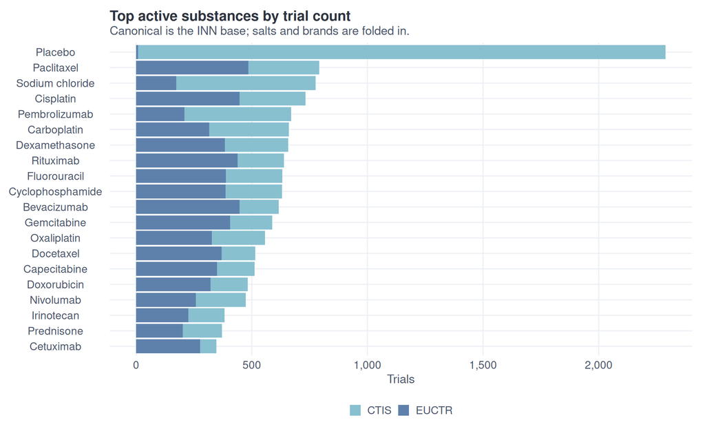

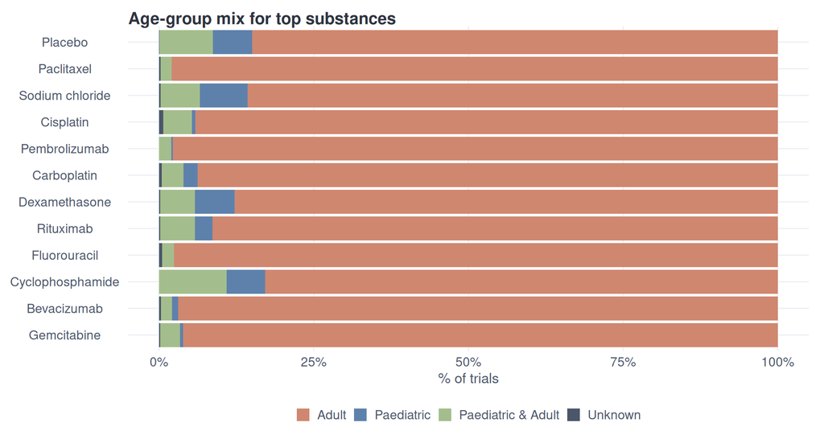

| raw_substance | n_trials | reason |
| --- | --- | --- |
| mL concentrate for solution for infusion | 457 | only dose/form/unit language remains after stripping |
| A | 375 | shorter than 3 characters |
| - | 352 | shorter than 3 characters |
| mL concentrate for solution for infusion. | 340 | only dose/form/unit language remains after stripping |
| N | 332 | shorter than 3 characters |
| Not available | 209 | placeholder text, not a substance |
| ml concentrate for solution for infusion | 189 | only dose/form/unit language remains after stripping |
| ml | 146 | shorter than 3 characters |
| ml Konzentrat zur Herstellung einer Infusionslösung | 112 | only dose/form/unit language remains after stripping |
| not available | 107 | placeholder text, not a substance |

[output cut: 907 more lines]

| raw_substance | proposed | confidence | n_trials | review_reason | reason | channel | model_id |
| --- | --- | --- | --- | --- | --- | --- | --- |
| California | A/California influenza strain | 0.7 | 34 | low confidence | Bare geographic word denotes influenza vaccine strain A/California; both spellings same component. | mint | claude-opus-5 |
| Forxiga 10 mg film-coated tablets | Dapagliflozin propanediol | 0.7 | 32 | low confidence | Forxiga is the brand name for dapagliflozin, marketed as the propanediol monohydrate salt. | token_idf | claude-sonnet-5 |
| Wisconsin | A/Wisconsin influenza strain | 0.7 | 28 | low confidence |  | mint | claude-sonnet-5 |
| Pertactin | Bordetella pertussis pertactin autotransporter | 0.7 | 27 | low confidence | Pertactin alone matches the single-antigen entry for Bordetella pertussis pertactin autotransporter, not the combination vaccines. | token_idf | claude-sonnet-5 |
| Malaysia | A/Malaysia influenza strain | 0.6 | 26 | low confidence | Bare geographic name representing an influenza vaccine strain designation | mint | claude-sonnet-5 |
| Haemagglutinin from A | Influenza A haemagglutinin | 0.8 | 25 | high impact, middling confidence | Influenza A haemagglutinin antigen | mint | claude-opus-5 |
| Haemagglutinin from B | Influenza B haemagglutinin | 0.8 | 25 | high impact, middling confidence |  | mint | claude-opus-5 |
| Brisbane | A/Brisbane influenza strain | 0.7 | 22 | low confidence | Bare geographic word denoting an influenza vaccine strain designation; both variants differ only in case. | mint | claude-opus-5 |
| Dexamethason 4 mg JENAPHARM® | Dexamethasone (sodium phosphate) | 0.85 | 22 | high impact, middling confidence | Dexamethason is the German name for dexamethasone; the sodium phosphate salt/base entry matches the parent INN dexamethasone. | token_idf | claude-sonnet-5 |
| Privigen 100 mg | Human normal immunoglobulin (ivig) | 0.85 | 21 | high impact, middling confidence | Privigen is a brand name for 10% human normal immunoglobulin for intravenous use (IVIg). | token_idf | claude-sonnet-5 |

[output cut: 4663 more lines]

| raw_substance | substance_clean | substance_salt | substance_type | match_status | confidence | decided_by | n_trials |
| --- | --- | --- | --- | --- | --- | --- | --- |
| PACLITAXEL | Paclitaxel |  |  | accepted | 1 | registry | 445 |
| KEYTRUDA 25 mg | Pembrolizumab |  |  | accepted | 1 | registry | 361 |
| CISPLATIN | Cisplatin |  |  | accepted | 1 | registry | 335 |
| RITUXIMAB | Rituximab |  |  | accepted | 1 | registry | 324 |
| CARBOPLATIN | Carboplatin |  |  | accepted | 1 | registry | 316 |
| DEXAMETHASONE | Dexamethasone | acetate |  | accepted | 1 | registry | 309 |
| CYCLOPHOSPHAMIDE | Cyclophosphamide | anhydrous |  | accepted | 1 | registry | 299 |
| BEVACIZUMAB | Bevacizumab |  |  | accepted | 1 | registry | 290 |
| OXALIPLATIN | Oxaliplatin |  |  | accepted | 1 | registry | 287 |
| FLUOROURACIL | Fluorouracil |  |  | accepted | 1 | registry | 259 |

[output cut: 34615 more lines]

# 5. PIP, Results, and Orphan Flags

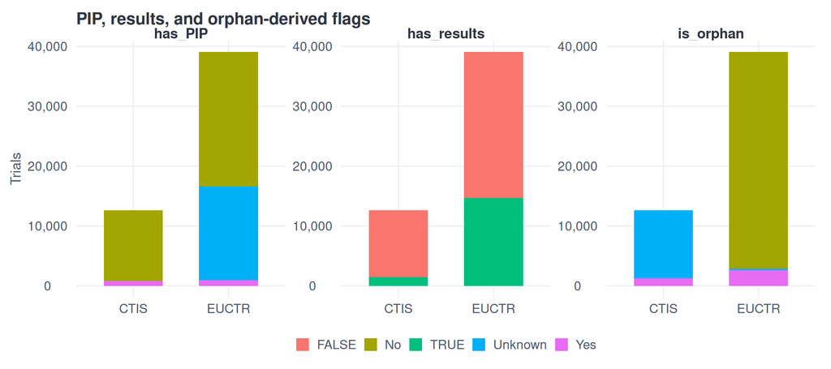

| Flag | register | Value | Trials | % within register |
| --- | --- | --- | --- | --- |
| has_PIP | CTIS | No | 11,793 | 93.4% |
| has_PIP | CTIS | Yes | 832 | 6.6% |
| has_PIP | EUCTR | No | 22,453 | 57.4% |
| has_PIP | EUCTR | Unknown | 15,717 | 40.2% |
| has_PIP | EUCTR | Yes | 920 | 2.4% |
| has_results | CTIS | FALSE | 11,139 | 88.2% |
| has_results | CTIS | TRUE | 1,486 | 11.8% |
| has_results | EUCTR | FALSE | 24,432 | 62.5% |
| has_results | EUCTR | TRUE | 14,658 | 37.5% |
| is_orphan | CTIS | Unknown | 11,356 | 89.9% |

[output cut: 4 more lines]

# 6. Completeness

| Column | Type | Non-missing | Complete (%) |
| --- | --- | --- | --- |
| authorizedPartI.trialDetails.trialInformation.trialDuration.estimatedRecruitmentStartDate | character | 0 | 0 |
| human_label | character | 0 | 0 |
| human_action | character | 0 | 0 |
| override_fields | character | 0 | 0 |
| sponsor_parent | character | 2207 | 4.3 |
| authorizedApplication.eudraCt.eudraCtCode | character | 4658 | 9 |
| transition_eudract_number | character | 4658 | 9 |
| authorizedApplication.authorizedPartI.trialDetails.trialInformation.trialDuration.estimatedRecruitmentStartDate | character | 12625 | 24.4 |
| authorizedApplication.authorizedPartI.trialDetails.trialInformation.trialDuration.estimatedEndDate | character | 12625 | 24.4 |
| ctStatus | character | 12625 | 24.4 |

[output cut: 71 more lines]

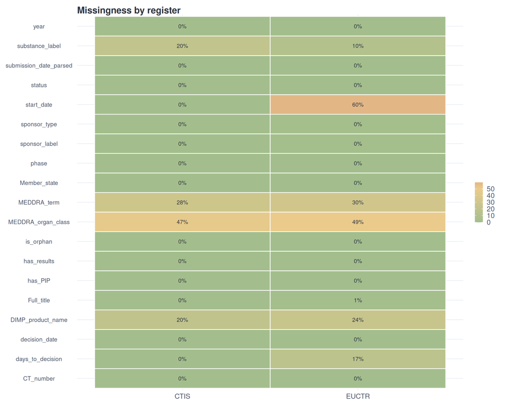

# 7. Data Quality Issues

## Summary

| Severity | Category | Issue | N affected | Suggested_action |
| --- | --- | --- | --- | --- |
| High | Deduplication | Residual cross-register duplicates by shared title key | 100 | Review title-only matches and require corroborating identifiers before automated collapse. |
| High | Deduplication | Transitioned EUCTR trials without a CTIS match in current fallbacks | 25 | Refresh CTIS data and inspect missing transition EudraCT identifiers. |
| High | Deduplication | Duplicate canonical trial IDs in final cache | 0 | Review canonical_trial_id derivation for transition aliases and latest-version preference. |
| High | Status | CTIS numeric status codes outside the current mapping | 0 | Extend CTIS status-code mapping if these codes are valid source values. |
| High | Dates | Completed trials with no decision_date | 16 | Add or audit decision-date fallbacks for completed trials. |
| Medium | Country | Country strings normalised to missing | 0 | Add unresolved country strings to the country lookup or preserve raw values for review. |
| Medium | Organ class | CTIS organ-class codes still stored as raw numbers | 0 | Extend the MedDRA SOC lookup for unresolved numeric CTIS codes. |
| Medium | Identifiers | Canonical trial IDs appearing more than once | 0 | Review duplicate canonical identities and remove duplicate real-world trials. |
| Medium | Sponsor | Sponsor labels still contain legal-entity tokens | 44 | Add sponsor aliases for fallback labels that still include legal suffixes. |
| Low | Status | Trials with status 'Other' | 0 | Review raw status values and extend status category patterns where warranted. |

[output cut: 2 more lines]

## Detail Tables

The tables below show examples for issues where example rows are available.

| EUCTR ID | CTIS ID | Shared title key | EUCTR status | CTIS status |
| --- | --- | --- | --- | --- |
| 2011-005766-38-PL | 2022-500079-30-00 | a phase 3 multicenter randomized double blind placebo controlled trial to evalua | Completed | Completed |
| 2018-000601-22-DE | 2022-500079-30-00 | a phase 3 multicenter randomized double blind placebo controlled trial to evalua | Completed | Completed |
| 2011-004844-23-ES | 2022-500090-13-00 | a phase 2 randomized double blind placebo controlled study to evaluate the effec | Completed | Completed |
| 2011-004845-42-CZ | 2022-500090-13-00 | a phase 2 randomized double blind placebo controlled study to evaluate the effec | Completed | Completed |
| 2008-001936-11-BE | 2022-500257-16-00 | a phase 3 multicenter randomized double blind study to evaluate the safety and e | Completed | Ongoing |
| 2013-001669-17-BE | 2022-500308-23-00 | a randomised controlled assessor blind parallel groups multicentre multinational | Completed | Ongoing |
| 2021-001785-38-AT | 2022-500308-23-00 | a randomised controlled assessor blind parallel groups multicentre multinational | Completed | Ongoing |
| 2018-001133-40-GB | 2022-500488-10-00 | an open label study to evaluate the safety and pharmacokinetics of migalastat hc | Administrative | Completed |
| 2018-000265-37-ES | 2022-500694-14-00 | phase 1 2 study investigating safety tolerability pharmacokinetics and prelimina | Completed | Completed |
| 2004-002016-28-AT | 2022-500699-76-00 | a phase 3 randomized double blind placebo controlled study to evaluate the effic | Completed | Ongoing |

[output cut: 90 more lines]

```
## No unmapped CTIS status codes were detected.
```

```
## No country strings normalised to missing.
```

```
## No unresolved numeric organ-class values.
```

```
## No duplicate canonical trial IDs.
```

| Sponsor label | N trials |
| --- | --- |
| Insel Gruppe AG | 9 |
| AMW GmbH | 4 |
| Diabetology Ltd | 2 |
| GB001, Inc. | 2 |
| Lukaskrankenhaus GmbH | 2 |
| Lung LLC | 2 |
| Wilhelminen Krebsforschung GmbH | 2 |
| Biomedizinische Forschung und Bio-Produkte AG | 1 |
| Cristcot HCA LLC | 1 |
| Diasolve Ltd | 1 |

[output cut: 18 more lines]

```
## No days_to_decision values above 10 years.
```

```
## No implausible submission years.
```

*Generated by `rmarkdown/preprocessing.Rmd` at 2026-10-22 03:04:52 UTC.*